# Stats & Probability

Material is lessons from Khan Academy, to refresh my memory and skills.

## Frequency Tables & Venn diagrams

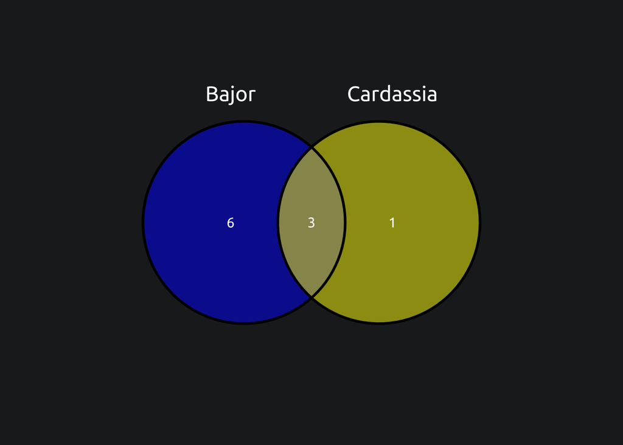

```r
# library(ggvenn)

circles = list('Bajor' = c(6,3), 'Cardassia' = c(1,3))

ggvenn(circles, set_name_color = 'white',
       show_elements = T,
       text_color = 'white')
```

- 6 people are Bajoran and not Cardassian
- 3 people are both Bajoran and Cardassian
- 1 person is Cardassian and not Bajoran

[output not shown]

## Two way frequency table

[output not shown]

# Descriptive Stats

Average = mean. Median = middle. Mode = most common number

```r
a = c(1,2,4,6,4)

sort(a)
```

```
## [1] 1 2 4 4 6
```

```r
total = sum(a)
n = length(a)

# avg = total/n
paste("the avg ", mean(a))
```

```
## [1] "the avg  3.4"
```

```r
paste("the middle", median(a))
```

```
## [1] "the middle 4"
```

```r
# mode(a)
```

```r
x = c(0,2,4,12,12,5,6,19)
mean(x)
```

```
## [1] 7.5
```

```r
v = c(80,90,92,94,96)
v2 = c(90,92,94,96)

paste(" mean with lowest value: ",mean(v))
```

```
## [1] " mean with lowest value:  90.4"
```

```r
paste(" mean without lowest value: ",mean(v2))
```

```
## [1] " mean without lowest value:  93"
```

athlete pulls avg to the right but median will be < mean

3 people make same money 50+50+50/3 =50 median = 50

3 unemployed pull avg left but median will be > mean

x points, remove 1 lowest value , the median move to the right, mean goes up

```
dots
  1   2  3  1  2     1
|-|-|-|--|--|--|--|--|-|-
6 7 8 9 10 11 12 13  14  distribution
```

## IQR

Interquartile range is the amount of spread in the middle %50 percent of a dataset.

```r
x = c(16,24,26,26,26,27,28)
# median       ^

median(x)
```

```
## [1] 26
```

```r
# mean(x)
# max(x)
# min(x)
range = max(x) - min(x)

# break into quartiles Q1 (25%)
x1 = c(16,24,26)
q1 = median(x1)

# Quartile 3 (75%)
x3 = c(26,27,28)
q3 = median(x3)

IQR = q3 - q1
IQR
```

```
## [1] 3
```

## Range, Variance & STD

Range (max - min) is the measure of dispersion, how far away from the mean (average) a data point is.

Variance $\sigma^2$

Standard Deviation $\sigma$ (the sqrt( variance))

```r
p1 = c(-10,0,10,20,30)
p2 = c(8,9,10,11,12)

# mean(p1) #= 10
# mean(p2) #= 10

# return the max and min for vector
range1 = range(p1)
# subtract the range elements to get range
range1 = range1[2]- range1[1] #= 40

range2 = range(p2)
range2 = range2[2] - range2[1] #= 4

# variance for p1 vector, (elements - mean)^2
v1 = (-10 - 10)^2 + (0-10)^2 + (10-10)^2 +(20-10)^2 +(30-10)^2
variance1 = v1 / length(p1)

# variance for p2 vector
v2 = (p2[1] - 10)^2 + (p2[2]-10)^2 + (p2[3]-10)^2 +(p2[4]-10)^2 +(p2[5]-10)^2
variance2 = v2 / length(p2)


# standard deviation, sqrt( variance )

std1 = sqrt(variance1)
std2 = sqrt(variance2)
```

## Population mean & variance

Population mean $\mu$ and variance $\sigma^2$ measures the dispersion

```r
# vector of population
pop = c( 8,1,2,6,1,4)

mean(pop)
```

```
## [1] 3.666667
```

```r
# length(pop)
median(pop)
```

```
## [1] 3
```

```r
# population mean
pop_mean = mean(pop)

# variance
variance = function(v, pop_mean){
  v2 = (v[1] - pop_mean)^2 +
    (v[2]-pop_mean)^2 +
    (v[3]-pop_mean)^2 +
    (v[4]-pop_mean)^2 +
    (v[5]-pop_mean)^2 +
    (v[6]-pop_mean)^2

  variance2 = v2 / length(v)
  print(variance2)
}

# variance(pop, pop_mean)

# standard deviation
print( sqrt( variance(pop, pop_mean) ) )
```

```
## [1] 6.888889
## [1] 2.624669
```

```r
sd(pop)
```

```
## [1] 2.875181
```

## Sample variance

Sample mean $x^-$ and sample variance $S^2_{n-1}$ . Standard deviation measures the spread of a data distribution. It measures the typical distance between each data point and the mean.

```r
s = c(13,2,1,5,2,7)

n = length(s)
n
```

```
## [1] 6
```

```r
# sort(s)

# sample mean
sm = mean(s)
paste('mean: ',sm)
```

```
## [1] "mean:  5"
```

```r
# median
median(s)
```

```
## [1] 3.5
```

```r
# ------ IQR
# sq1 = c(2.6, 3.0, 4.9, 5.0, 5.0)
# sm1 =median(sq1)
# sq2 = c(6.0, 6.0, 7.9, 8.0 ,8.2)
# sm2 = median(sq2)
#
# sm2 - sm1

# IQR(s) gives off values

# sample variance (unbiased)// only 5 number //   var(s) gives off values
variance(s, sm )
```

```
## [1] 17
```

```r
# for >5 numbers
s_2 = (s[1]- sm)^2 +
  (s[2] - sm)^2 +
  (s[3] - sm)^2 +
  (s[4]- sm)^2 +
  (s[5]- sm)^2 +
  (s[6] - sm)^2

s_2
```

```
## [1] 102
```

```r
# population variance
paste('pop var: ', s_2 / (n -1))
```

```
## [1] "pop var:  20.4"
```

```r
# sample variance
paste('sample var: ', s_2 / n )
```

```
## [1] "sample var:  17"
```

```r
# sample std (biased)  sd(x) gives off values
sqrt(variance(s, sm ))
```

```
## [1] 17
```

```
## [1] 4.123106
```

## Box & Whisker Boxplot

spread of data points.

- whiskers are range
- middle box line is median
- outside box lines are quartiles median

Outliers

- find the median
- use the medians of q1 and q3

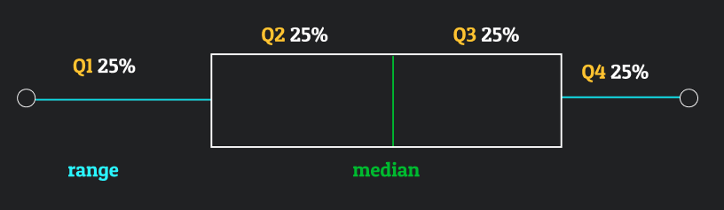

```r
b = c(52,54,56,58 )
b = c(10,52,54,56,58 )


paste('mean = ', mean(b) )
```

```
## [1] "mean =  46"
```

```r
paste('median = ', median(b) )# q2
```

```
## [1] "median =  54"
```

```r
q1 = c( 4 , 4 , 6,  7 )
paste('Q1 ',median(q1))
```

```
## [1] "Q1  5"
```

```r
q3 = c(  11 ,12 ,14 ,15  )
paste('Q3 ',median(q3))
```

```
## [1] "Q3  13"
```

```r
iqr = median(q3) - median(q1)
paste(' IQR = ',iqr)
```

```
## [1] " IQR =  8"
```

```r
# outliers will be < q1 - 1.5 * IQR  or q3 + 1.5 * IQR
outlier_1 = median(q1) - 1.5 * iqr
paste('outlier is <= ', outlier_1)
```

```
## [1] "outlier is <=  -7"
```

```r
outlier_2 = median(q3) + 1.5 * iqr
paste('outlier is >= ', outlier_2)
```

```
## [1] "outlier is >=  25"
```

```r
# ------------
# 3 6 12 13 39 = 2 <- high  0  <- low
# 13 31 38 42 62 = 1
# 4 9 10 13 20 = 0
# 13 24 30 40 138 = 0
# 1 2 3 5 9 = 0

q1 = 13
q3 = 6
i= q3 -q1

q1 - 1.5 * i
```

```
## [1] 23.5
```

```r
q3 + 1.5 * i
```

```
## [1] -4.5
```

## Mean Absolute Deviation (MAD)

the absolute deviation data point from the mean

```r
m = c(0.3,0.6,0.5,1,0.4,0.8 )

mean(m)
```

```
## [1] 0.6
```

```r
# n = c(4,5,6,1)
# mean(n)

# paste('MAD = ', stats::mad(m) )

w =c(
  abs( mean(m) - m[1] ),
  abs( mean(m) - m[2] )  ,
  abs( mean(m) - m[3] ) ,
  abs( mean(m) - m[4] ) ,
  abs( mean(m) - m[5] ),
  abs( mean(m) - m[6] )
)

paste('MAD : ',sum(w)/ length(m) )
```

```
## [1] "MAD :  0.2"
```

# Percentiles

the % of the data that is below the amount in question or % of the data at or below the amount

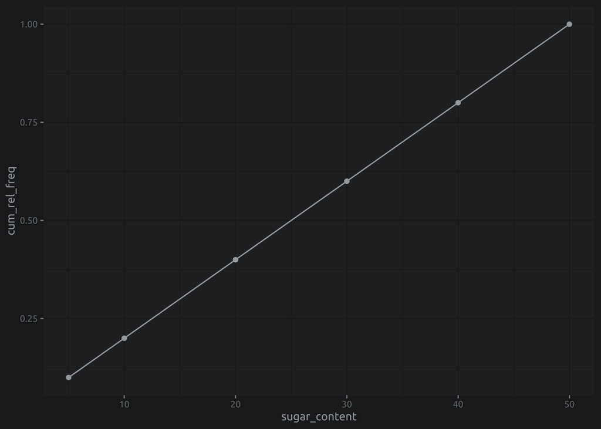

```r
# number of 14 drivers in total
# what percentile rank for driver with driving time of 6 hrs?
# h = c(1,2,2,3,4,5,5) # below 6  7 numbers/ 14 = 50%
# h.1 = c(1,2,2,3,4,5,5,6) # at 6  8/14 = 57%

# cumulative relative frequency
sugar = tibble(
  sugar_content = c(5, 10, 20, 30, 40, 50),
  cum_rel_freq = c(0.1,0.2,0.4,0.6,0.8,1.0)
)
ggplot(
  sugar,
  aes(x= sugar_content, y= cum_rel_freq)
)+
  geom_line()+
  geom_point()
```

what is the median are in what grams ? 0.5 = ~ 25 grams

# Z-Scores

measures how many standard deviations away from the mean

- z = $x$ - $\mu$ / $\sigma$
- positive z-score = above average
- negative z-score = below average
- 0 z-score = close to average
- *unusual* if z-score is < 3 or > 3

```r
# mean
mean = 76
std = 3.0

# data point
data_point = 71

# positive & negative points on plot
z_pos = mean + std
z_neg = mean - std

z_score = (data_point - mean) / std

paste('z score: ', round(z_score,2), 'std from the mean')
```

```
## [1] "z score:  -1.67 std from the mean"
```

shifting data: you add 5 to each data column or multiply by 5 the mean, median don’t change but IQR and std scale with the data.

# Density Curves

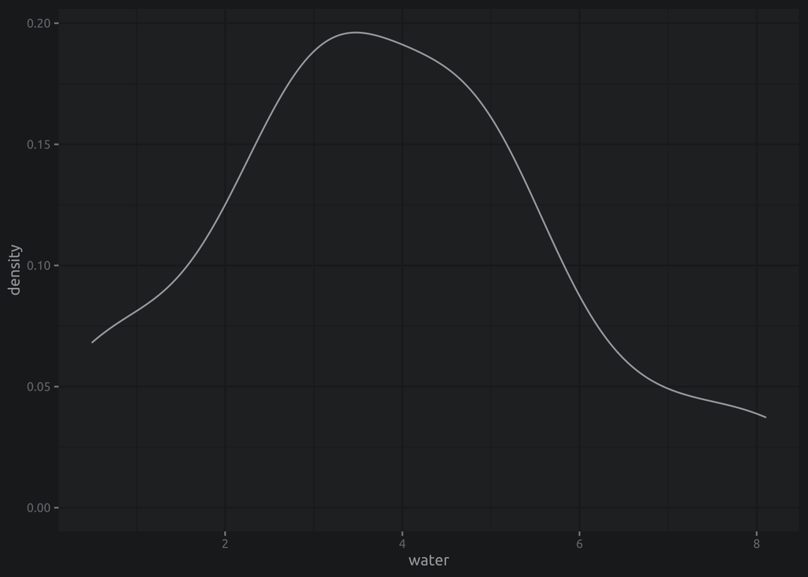

```r
water = c(0.5,0.7,2.1,2.2,2.9,3.2,3.2,3.3,3.7,4.5,4.6,4.8,5.2,5.3,6.7,8.1)

df = tibble(
  water = water,
  count = frequency(water)
)

ggplot(
  df,
  aes(x= water)
) +
  geom_density()
```

need an interval for getting a approximate value >= 2.9 + <= 3.1 is ~ 0.04%

right skewed (bump on left) = median is left to mean

left skewed (bump on right) = median is right to mean

density curve, % of area under density curve x > 3

# Normal Distribution

```r
mean = 150
std = 20
data_point = 161.4

z_pos = mean + std
z_neg = mean - std

# what proportion is lower than data point?
z_score = (data_point - mean) / std

paste('z score: ', round(z_score,2), 'std from the mean')
```

```
## [1] "z score:  0.57 std from the mean"
```

```r
# look at z-table using our z-score

# the z value is 0.7157
```

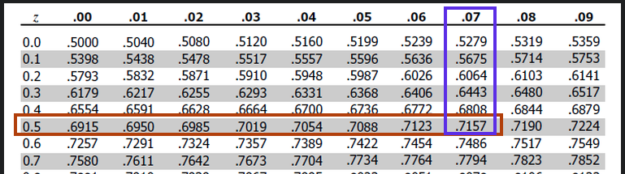

If the data is normally distributed, then 71.5% of the values would be below 0.57. The proportion is 0.7157.

## school test example

```r
mean = 40
std = 3
data_point = 47.5

z_pos = mean + std
z_neg = mean - std

# what proportion is lower than data point?
z_score = (data_point - mean) / std

paste('z score: ', round(z_score,2), 'std from the mean')
```

```
## [1] "z score:  2.5 std from the mean"
```

```r
# proportion LESS than data point
z_table = 0.9938

# proportion that scores MORE than data point
paste('proportion higher than data point: ', round(1 - z_table, 4) )
```

```
## [1] "proportion higher than data point:  0.0062"
```

## prices between range example

```r
mean = 70
std = 5

# -- data points
data_point_1 = 68
data_point_2 = 73

# what proportion is lower than data point?
z_1score = (data_point_1 - mean) / std
z_2score = (data_point_2 - mean) / std
glue::glue('z_1 score: {data_point_1} : {round(z_1score,4)} std from the mean')
```

```
## z_1 score: 68 : -0.4 std from the mean
```

```r
glue::glue('z_2 score: {data_point_2} : {round(z_2score,4)} std from the mean')
```

```
## z_2 score: 73 : 0.6 std from the mean
```

```r
#---- look at Z TABLE -----
# proportion LESS than data point
# z_table = 0.10565


# >>>>>>>>>>>>>>>>>
# proportion that scores MORE than data point
paste('proportion higher than data point: ', round(1 - z_table, 4) )
```

```
## [1] "proportion higher than data point:  0.0062"
```

```r
# -----------
# proportion of prices between range

# z score for data point 1 = -0.4 -->> look at z-table
z_1 = 0.3445

# z score for data point 2 = 0.6
z_2 = 0.7257
glue::glue(' proportion between range: {(z_2 - z_1)*100}%')
```

```
##  proportion between range: 38.12%
```

```r
# glue::glue(' proportion between range :: {(z_1 - z_2)*100}%')
```

## z-table reverse example

```r
mean = 85
std = 29

# z_pos = mean + std
# z_neg = mean - std

#>>>>>>>>>>> no data point given
# use z table in reverse, use x % to find z-score

#  EX.: looking for scores < 25%
#  read z-table from INSIDE TABLE then outward,
#  find closest value  == 0.24825
# >>>>>>>>>>>>

#  x% =  left of 5% == 0.05  closest {0.4947}
z_score = -1.65

# rate = mean + z_score * std
# rate
#
# paste('rate for (%): ', ceiling(rate))
```

## Empiracal rule

rule **68-95-99.9**

- 68% of data is within 1 std of the mean
- 95% of data is within 2 std of the mean
- 99.9% of data is within 3 std of the mean

```r
mean = 9.5
std = 11

z_pos = mean + std
z_neg = mean - std
glue::glue('| z {z_neg} --- z +{z_pos} |')
```

```
## | z -1.5 --- z +20.5 |
```

```r
#>>>> no data point given
# rates in the top 30%, so need to 100-10= 90% of data range
# use z table in reverse, use % to find z-score
# find % 0.9015 == 1.29 z-score
# z_score = 1.29

# within 10%
z_score = -1.29

# mean + 0.53 * 9
rate = mean + z_score * std
rate
```

```
## [1] -4.69
```

# Scatterplots

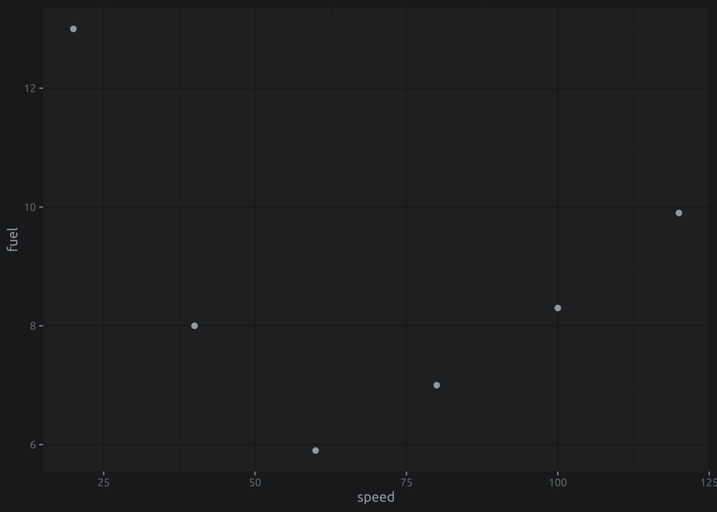

```r
df = data.frame(
  speed = c(20,40,60,80,100,120),
  fuel = c(13.0,8.0,5.9,7.0,8.3,9.9)
)

df %>%
  ggplot(
    aes(x= speed, y= fuel)
  )+
  geom_point()
```

# Correlation coefficients

Correlation coefficients are trying to measure the strength of a linear model can be described the relationship between 2 variables

```
when r = 1    closer to 1 is **strong** positive linear relationship (y > x)
when r = -1   negative linear relationship (x > y)
when r = 0    no line fit, no correlation
when r = 0.5  weak positive correlation
```

## Calculating bivariate correlation

```r
df = data.frame(
  x = c(1,2,2,3),
  y = c(1,2,3,6)
)

sample_mean.x = mean(df$x)
sample_std.x = sd(df$x)

sample_mean.y = mean(df$y)
sample_std.y = sd(df$y)


#--------------- compute correlations (r)
# -1 =< r =< +1
# our r = 0.945 close to +1
cor(df, method = 'pearson')
```

```
##           x         y
## x 1.0000000 0.9449112
## y 0.9449112 1.0000000
```

```r
cor.test(df$x, df$y, method = 'pearson')
```

```
##
##  Pearson's product-moment correlation
##
## data:  df$x and df$y
## t = 4.0825, df = 2, p-value = 0.05509
## alternative hypothesis: true correlation is not equal to 0
## 95 percent confidence interval:
##  -0.1760967  0.9988766
## sample estimates:
##       cor
## 0.9449112
```

# Linear Regression

simple linear regression is used to predict a quantitative outcome y on the basis of one single predictor variable x. The goal is to build a mathematical model (or formula) that defines y as a function of the x variable.

**Formula** : `y = b0 + b1 * x + e`

- b0 & b1 are regression coefficients
- b0 = intercept (predicted value when x = 0)
- b1 is the slope pf regression line

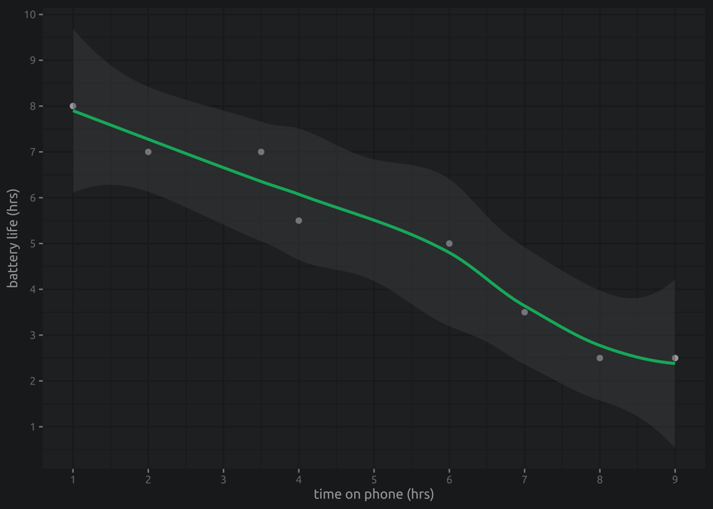

```r
df = tibble(
  x = c(1,2,3.5,4,6,7,8,9),
  y = c(8,7,7,5.5,5,3.5,2.5,2.5)
)



df %>%
  ggplot( aes(x= x, y= y)) +
  geom_point() +
  geom_smooth()+
  scale_x_continuous(breaks = c(1:10))+
  scale_y_continuous(breaks = c(1:10) )+
  labs(y="battery life (hrs)", x="time on phone (hrs)")
```

### Example

line goes through (0,40) and (10,35) : the very start of the line and where the x data point intersect with line

- slope (y2: 35 - y1: 40) / (x2: 10 - x1: 0)
- slope **m** = - 0.5
- y-intercept is y1: 40
- **y = mx + b**
- equation: y = -0.5 * x + 40

Estimate % of x, say x is 30

- y = (-0.5) * (30) + 40 = 25

```r
#   (y2 - y1) / (x2 - x1)   (0, 5) (1.5, 7 ) <<-- line meets vertical line
m = (2 - 0) / (1-0)

b = 7.5
x = 5.5
y = m *x + b
y
```

```
## [1] 18.5
```

```r
# = 8.75

# (0, 5) (1.5, 7 ) = 8.75
# (0, 40) (10,35 ) = 25
# (0, 7.5) (0.5, 7 ) = 2
# (1, 2) (2, 4.5) = 2.25 [2.5*1.10 - 0.5]
```

## Residuals & Least Squares Regression

Residuals are the amount the data point is above or below the regression line

how good is your model based on all residuals => least squares regression

**residuals closer to 0 are better fit**

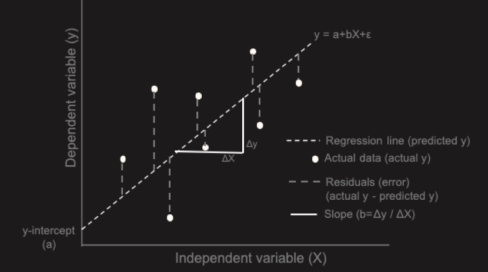

### least squares regression equation:

- residual = (observed y) - (predicted y)
- residual = y - y_hat

```r
# predict cost of oil barrel from cost crude oil

# what is the RESIDUAL of {observed}  ... x
observed = 2
x = 50000

# predict
y_hat = 11000 + 18000* x
y_hat
```

```
## [1] 900011000
```

```r
residual = observed - y_hat
residual
```

```
## [1] -900010998
```

```r
# -----------



# what is the residual of 2 ... 50,000
x = 2
y_hat = 11000 + 18000 * x

observed = 50000

residual = observed - y_hat
residual
```

```
## [1] 3000
```

### Least Squares Line

Find the equation of least squares regression line to predict

1. find slope : b = r* (std_y / std_x)
2. find y-intercept, regression line passes (x, y)
- `a = y_hat - bz`
3. predict y from x : `y_hat = a + bx`.
- a is y-intercept
- b is the slope

```r
sample_mean.x = 12.2
sample_std.x = 5.2

sample_mean.y = 1.1
sample_std.y = 1.3

residual = 0.65
# ------------
x = 1

b = residual * (sample_std.y / sample_std.x)
b
```

```
## [1] 0.1625
```

```r
a = sample_mean.y - b * sample_mean.x
a
```

```
## [1] -0.8825
```

```r
# y_hat = a + bx
y_hat = a + b * x
glue('y_hat = {round(a,2)} + {round(b,2)} * x = {y_hat}')
```

```
## y_hat = -0.88 + 0.16 * x = -0.72
```

```r
# a = y_hat - bx
a.2 = sample_mean.y - b * sample_mean.x
glue('y_hat = {a.2} - {(b)} * x = {y_hat}')
```

```
## y_hat = -0.8825 - 0.1625 * x = -0.72
```

### RMSE

$R^2$ or coefficient of determination is about how much or what % of the total variance is explained and not explained in the regression line

$R^2$ = 1 - standard error of line / standard error y_hat

[output not shown]

for more than bivariate regression the Adjusted R-squared value matters